# Case study on the lupus dataset

Jeroen Gilis & Laura Perin

15/11/2023

# 1 Load libraries

```r
library(SingleCellExperiment)
library(ggplot2)
library(Matrix)
library(edgeR)
library(scuttle)
library(iCOBRA)
library(patchwork)
library(scater)
library(ComplexHeatmap)
library(EnhancedVolcano)
library(dplyr)
library(pbapply)
library(stageR)
library(harmonicmeanp)
library(scran)
```

# 2 Set project root

```r
here_root <- "Lupus"
here::i_am(file.path(here_root, "02_lupus_case.Rmd"))
```

```
## here() starts at /Users/jg/Desktop/PhD/DD_project/DD_cases
```

# 3 Load helper functions

```r
source("03_LupusCase_HelperFunctions.R")
```

# 4 Load filtered data

```r
sce_list <- readRDS("./objects/sce_sep_filt.rds")
sce_list <- lapply(sce_list, function(x){
    x$Age <- as.numeric(as.character(x$Age)) # Age: factor -> numeric
    return(x)
})
```

# 5 Pseudobulk aggregation

```r
pb_list <- lapply(sce_list, function(element){
  aggregateAcrossCells(element,ids=element$ind_cov)
})
```

# 6 Data exploration

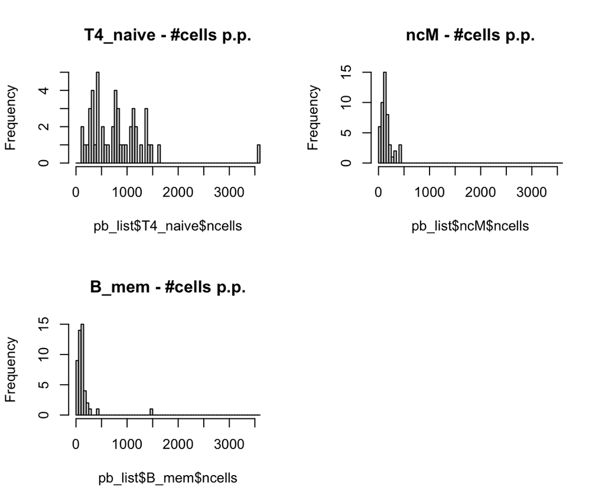

```r
par(mfrow=c(2,2))
hist(pb_list$T4_naive$ncells, breaks=seq(0,3600,50), xlim = c(0,3600),
     main = "T4_naive - #cells p.p.")
hist(pb_list$ncM$ncells, breaks=seq(0,3600,50), xlim = c(0,3600),
     main = "ncM - #cells p.p.")
hist(pb_list$B_mem$ncells, breaks=seq(0,3600,50), xlim = c(0,3600),
     main = "B_mem - #cells p.p.")
```

```r
# number of healthy/lupus patients in each batch, per cell type
table(pb_list$T4_naive$batch_cov, pb_list$T4_naive$Status)
```

```
##
##                      Healthy Managed
##   dmx_YS-JY-20_pool3       4       6
##   dmx_YS-JY-20_pool4       7       6
##   dmx_YS-JY-21_pool1       2       4
##   dmx_YS-JY-21_pool2       2       3
##   dmx_YS-JY-22_pool5       3       3
##   dmx_YS-JY-22_pool6       4       4
```

```r
table(pb_list$ncM$batch_cov, pb_list$ncM$Status)
```

```
##
##                      Healthy Managed
##   dmx_YS-JY-20_pool3       4       6
##   dmx_YS-JY-20_pool4       7       6
##   dmx_YS-JY-21_pool1       2       4
##   dmx_YS-JY-21_pool2       2       3
##   dmx_YS-JY-22_pool5       3       3
##   dmx_YS-JY-22_pool6       4       4
```

```r
table(pb_list$B_mem$batch_cov, pb_list$B_mem$Status) # 1 patient less (pool 4 managed)
```

```
##
##                      Healthy Managed
##   dmx_YS-JY-20_pool3       4       6
##   dmx_YS-JY-20_pool4       7       5
##   dmx_YS-JY-21_pool1       2       4
##   dmx_YS-JY-21_pool2       2       3
##   dmx_YS-JY-22_pool5       3       3
##   dmx_YS-JY-22_pool6       4       4
```

# 7 Dimension reduction

Here, we briefly inspect the data in reduced dimension space using tSNE. These figures were not used in our manuscript.

```r
# Normalization
pb_list <- lapply(pb_list, function(x){
    sf <- librarySizeFactors(x)
    x <- logNormCounts(x,size.factors=sf)
    return(x)
})

# Get 10% most variable genes
hvg_list <- lapply(pb_list, function(x){
    dec <- modelGeneVar(x)
    fit <- metadata(dec)
    hvg <- getTopHVGs(dec, prop=0.1)
    return(hvg)
})

# Run PCA
set.seed(1234)
pb_list <- lapply(seq_along(pb_list), function(i){
    runPCA(pb_list[[i]],
           ncomponents=30,
           subset_row=hvg_list[[i]])
})
# Run tSNE
pb_list <- lapply(pb_list, function(x){
    runTSNE(x,
           dimred = 'PCA',
           n_dimred = 10,
           external_neighbors=TRUE)
})

names(pb_list) <- c("B_mem", "ncM", "T4_naive")
```

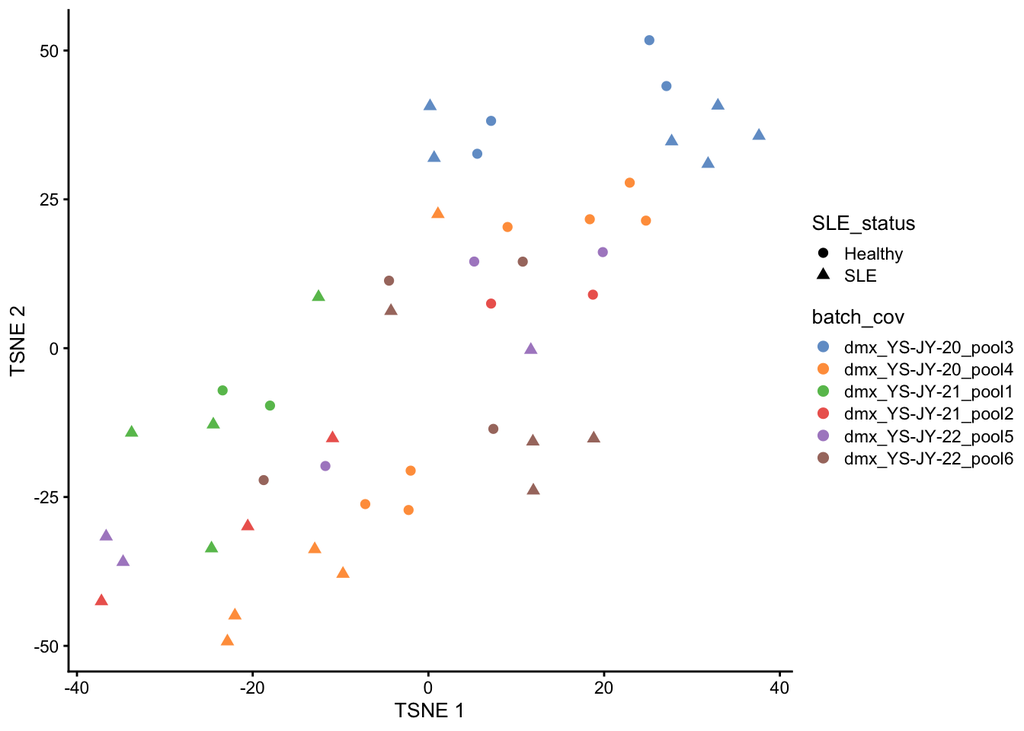

```r
plotTSNE(pb_list$B_mem,
         shape_by = "SLE_status",
         colour_by = "batch_cov",
         point_size=2,
         point_alpha = 1)
```

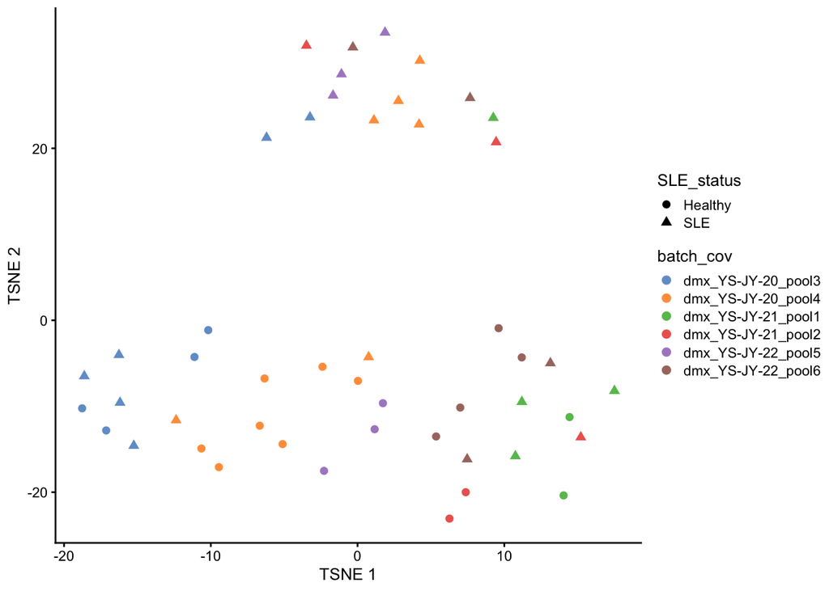

```r
plotTSNE(pb_list$ncM,
         shape_by = "SLE_status",
         colour_by = "batch_cov",
         point_size=2,
         point_alpha = 1)
```

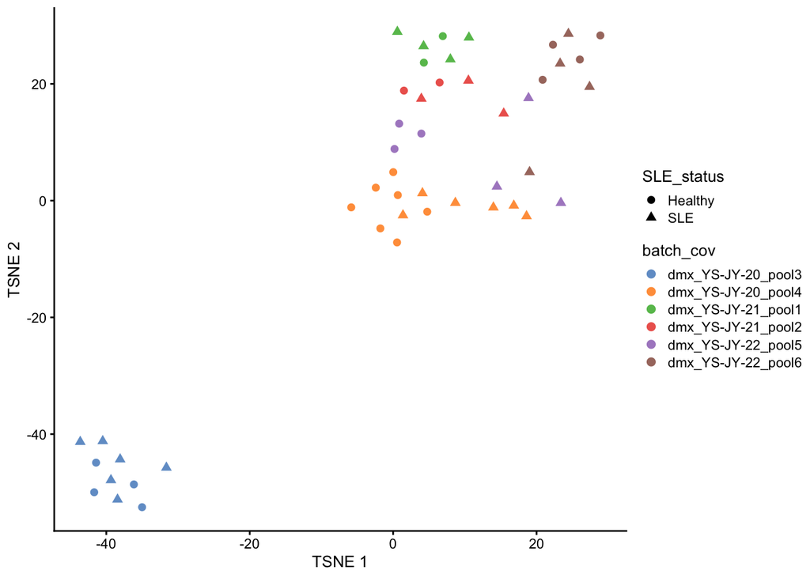

```r
plotTSNE(pb_list$T4_naive,
         shape_by = "SLE_status",
         colour_by = "batch_cov",
         point_size = 2,
         point_alpha = 1)
```

The patterns in the reduced dimensional space seem to differ between the different cell type: - For the B memory cells, there does not seem to be a strong effect of disease status. Patients of the same batch somewhat cluster together, but the effect is not too pronounced. There does seem to be another covariate at play that is dividing patients of the same batch that is not disease status, but coloring on any of the other covariates in the data did not result in identifying this covariate (suggests an unobserved confounder) - For nCM cells, there is a clear effect of disease status. Within disease status, patients cluster by batch - For T4 naive cells, there is a clear batch effect. One batch clusters completely separately from the others. Within batch, patients cluster by disease status

# 8 Differential expression analysis: edgeR

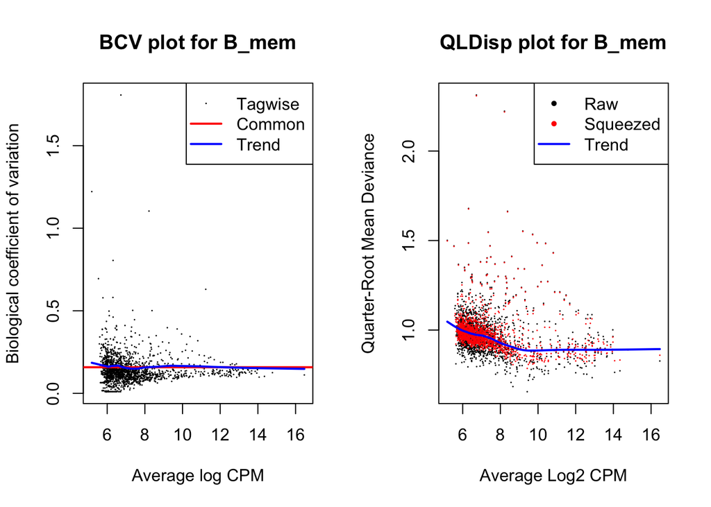

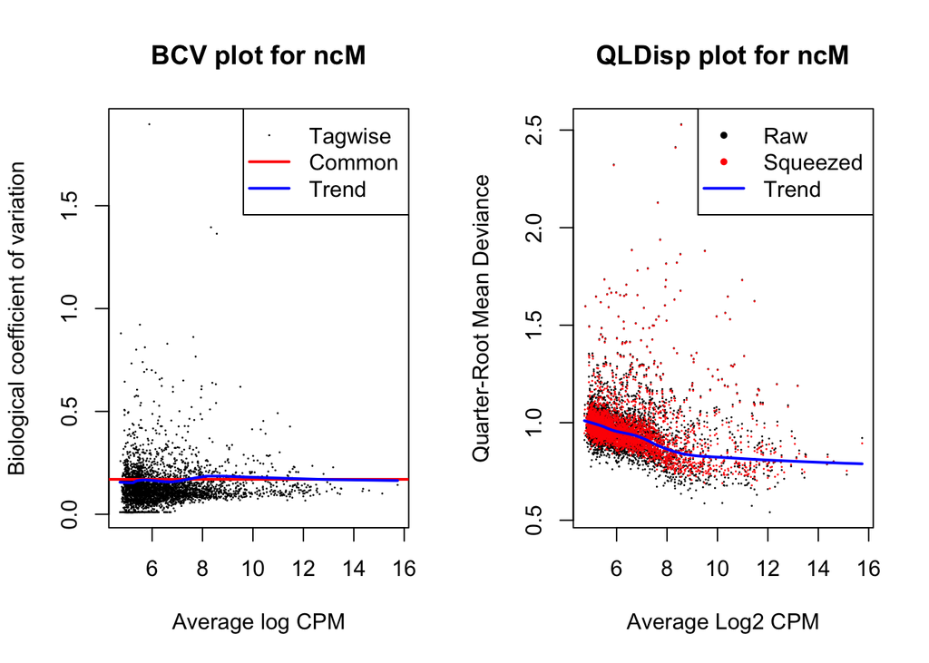

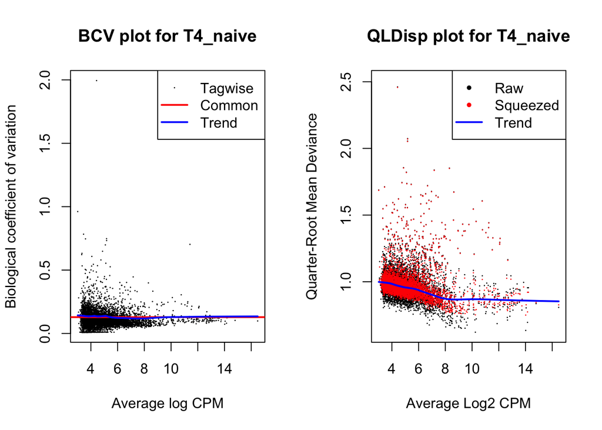

```r
DGE_res <- pblapply(pb_list, function(element){
    ct <- levels(droplevels(element$ct_cov))
    y <- DGEList(counts=counts(element), samples=colData(element))
    y <- calcNormFactors(y)
    design <- model.matrix(~ factor(batch_cov) + factor(SLE_status) + Age, y$samples)
    y <- estimateDisp(y,design)
    fit <- glmQLFit(y,design,robust=T)
    res <- glmQLFTest(fit,coef = "factor(SLE_status)SLE")

    par(mfrow=c(1,2))
    plotBCV(y, main = paste0("BCV plot for ", ct))
    plotQLDisp(fit, main = paste0("QLDisp plot for ", ct))

    return(res$table)
})
```

# 9 Differential detection analysis: edgeR-NB_optim

## 9.1 Binarization and pseudobulk aggregation

```r
pb_bin_list <- lapply(sce_list, function(element){
  assay(element)[assay(element)>=1] <- 1
  aggregateAcrossCells(element,ids=element$ind_cov)
})
```

## 9.2 Analysis

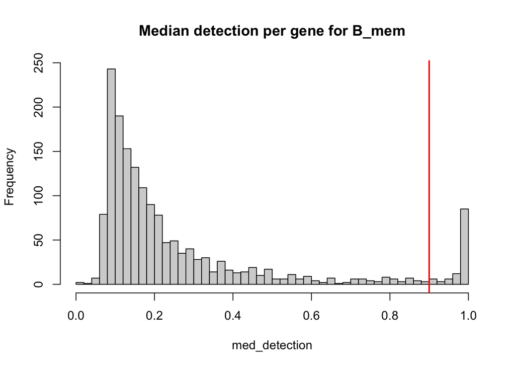

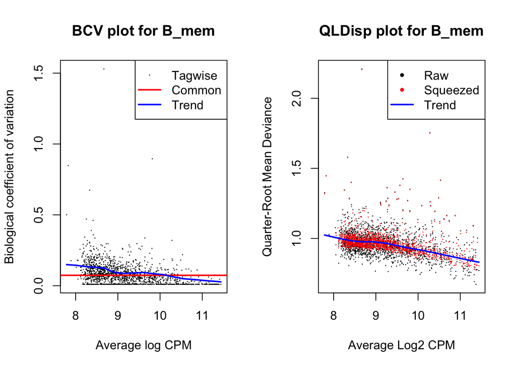

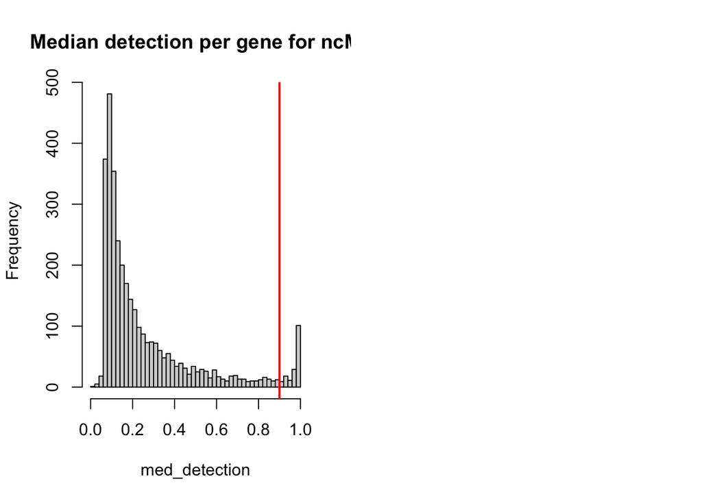

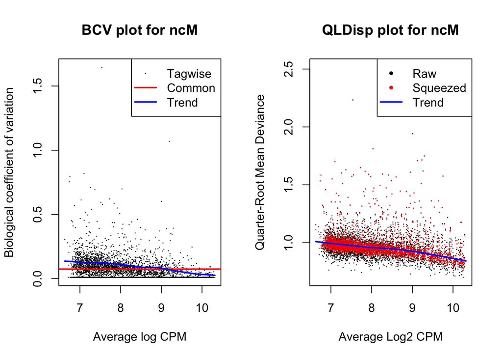

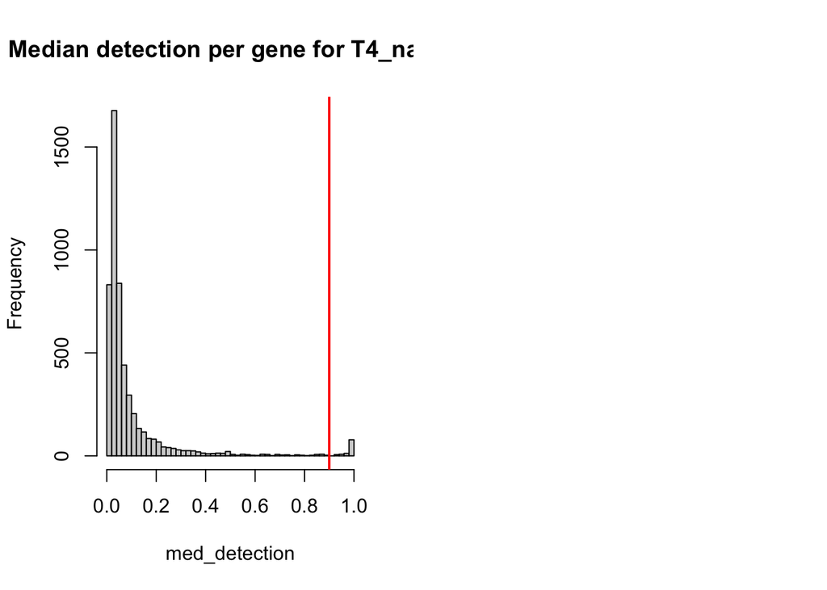

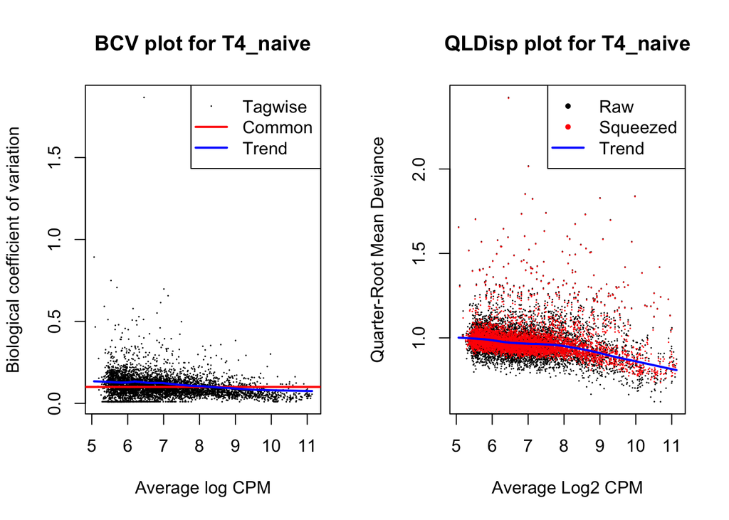

```r
DD_res <- pblapply(pb_bin_list, function(element){
    ct <- levels(droplevels(element$ct_cov))
    med_detection <- rowMedians(sweep(assay(element), 2, element$ncells, "/"))
    hist(med_detection, breaks=40,
         main = paste0("Median detection per gene for ", ct))
    abline(v=0.9, col="red", lwd=2)

    y <- DGEList(counts=assay(element)[med_detection < 0.9,],
                 samples=colData(element))
    design <- model.matrix(~ factor(batch_cov) + factor(SLE_status) + Age, y$samples)

    of <- colMeans(sweep(assay(element)[med_detection < 0.9,], 2, element$ncells, "/"))
    y$offset <- log(element$ncells*of)

    y <- estimateDisp(y,design)
    fit <- glmQLFit(y,design,robust=T)
    res <- glmQLFTest(fit,coef = "factor(SLE_status)SLE", poisson.bound = FALSE)
    #res <- glmTreat(fit,coef = ncol(design), lfc=0.2)

    par(mfrow=c(1,2))
    plotBCV(y, main = paste0("BCV plot for ", ct))
    plotQLDisp(fit, main = paste0("QLDisp plot for ", ct))

    return(res$table)
})
```

# 10 Stagewise testing

Note: by removing genes that are detected in (nearly) all samples in the differential detection analysis but not the differential expression analysis, the results will be of different dimensions. For easy comparison between the two analyses, I will here fill in `NA` values for the genes that were removed in the DD analysis

```r
for(i in seq_along(DD_res)){
  removed <- which(!rownames(DGE_res[[i]]) %in% rownames(DD_res[[i]])) # detect removed genes
  DD_res[[i]][nrow(DD_res[[i]]) + length(removed),] <- NA # add NA values for removed genes
  rownames(DD_res[[i]])[(nrow(DD_res[[i]])-length(removed)+1):nrow(DD_res[[i]])] <- rownames(DGE_res[[i]])[removed] # add rownames for removed genes
  DD_res[[i]] <- DD_res[[i]][match(rownames(DGE_res[[i]]), rownames(DD_res[[i]])),] # correct order
}
```

```r
DD_DE_Sig <- lapply(1:3, function(i){

    pScreen <- rep(NA, nrow(DD_res[[i]]))
    for(h in 1:length(pScreen)){
        if(is.na(DD_res[[i]]$PValue[h])){
          pScreen[h] <- DGE_res[[i]]$PValue[h]
        } else {
          pScreen[h] <- hmp.stat(c(DD_res[[i]]$PValue[h],
                                   DGE_res[[i]]$PValue[h]),
                                 w=NULL)
        }
    }
    names(pScreen) <- rownames(DD_res[[i]])

    #confirmation stage
    pConfirmation <- as.matrix(cbind(DD_res[[i]]$PValue,
                                     DGE_res[[i]]$PValue))
    dimnames(pConfirmation) <- list(rownames(DD_res[[i]]), c("DD","DE"))

    # stageWise analysis
    stageRObj <- stageR(pScreen=pScreen,
                        pConfirmation=pConfirmation,
                        pScreenAdjusted=FALSE)
    stageRObj <- stageWiseAdjustment(object=stageRObj,
                                     method="none",
                                     alpha=0.05,
                                     allowNA = TRUE)
    res <- getResults(stageRObj)
    print(sum(res[,1]))

    DD_DE_Sig_i <- getAdjustedPValues(stageRObj,
                                      onlySignificantGenes=FALSE,
                                      order=FALSE)
    return(DD_DE_Sig_i)
})
```

```
## [1] 64
## [1] 382
## [1] 264
```

```r
names(DD_DE_Sig) <- c("B_mem", "ncM", "T4_naive")
```

# 11 Manuscript table 3

```r
# Table 3 for manuscript
overlap_DE_DD <- sapply(c(3,1,2), function(i){
    length(intersect(which(p.adjust(DGE_res[[i]]$PValue, method="BH") < 0.05),
                     which(p.adjust(DD_res[[i]]$PValue, method="BH") < 0.05)))
})

overlap_DE2_DD2 <- sapply(c(3,1,2), function(i){
    length(intersect(names(which(DD_DE_Sig[[i]][,2] < 0.05)),
          names(which(DD_DE_Sig[[i]][,3] < 0.05))))
})

overlap_DE_DE2 <- sapply(c(3,1,2), function(i){
    length(intersect(rownames(DGE_res[[i]])[p.adjust(DGE_res[[i]]$PValue, method="BH") < 0.05],
                     names(which(DD_DE_Sig[[i]][,3] < 0.05))))
})

overlap_DD_DD2 <- sapply(c(3,1,2), function(i){
    length(intersect(rownames(DD_res[[i]])[p.adjust(DD_res[[i]]$PValue, method="BH") < 0.05],
                     names(which(DD_DE_Sig[[i]][,2] < 0.05))))
})


DE_ind <- sapply(DGE_res[c(3,1,2)], function(x){sum(p.adjust(x$PValue, method = "BH") < 0.05, na.rm = TRUE)})
DD_ind <- sapply(DD_res[c(3,1,2)], function(x){sum(p.adjust(x$PValue, method = "BH") < 0.05, na.rm = TRUE)})

table3 <- data.frame(Comparison = 1:3,
                     "Cell Type" = c("T4 Naive", "B Memory", "nCM"),
                     DE = DE_ind,
                     DD = DD_ind,
                     Omnibus = sapply(DD_DE_Sig[c(3,1,2)], function(x){sum(x[,1] < 0.05)}),
                     DEstage2 = sapply(DD_DE_Sig[c(3,1,2)], function(x){sum(x[,3] < 0.05, na.rm=TRUE)}),
                     DDstage2 = sapply(DD_DE_Sig[c(3,1,2)], function(x){sum(x[,2] < 0.05, na.rm=TRUE)}),
                     overlap_DE_DD = overlap_DE_DD,
                     overlap_DE2_DD2 = overlap_DE2_DD2,
                     overlap_DE_DE2 = overlap_DE_DE2,
                     overlap_DD_DD2 = overlap_DD_DD2,
                     row.names = NULL)
table3
```

```
##   Comparison Cell.Type  DE  DD Omnibus DEstage2 DDstage2 overlap_DE_DD
## 1          1  T4 Naive 248 170     264      242      189           146
## 2          2  B Memory  58  33      64       56       36            27
## 3          3       nCM 340 266     382      334      277           209
##   overlap_DE2_DD2 overlap_DE_DE2 overlap_DD_DD2
## 1             167            237            170
## 2              28             54             33
## 3             229            329            259
```

# 12 pval-pval

```r
plotDataList <- vector(mode = "list", length = 3)
plotList <- vector(mode = "list", length = 3)
titles <- c("Panel A: B memory cells", "Panel B: Non-classical myeloid cells",
            "Panel C: T4 naive cells")

for(i in 1:3){

bin_counts <- assay(pb_bin_list[[i]])
cd <- colData(pb_bin_list[[i]])
cd <- droplevels(cd)
detection <- rowMeans(sweep(bin_counts, 2, cd$ncells, "/"))

counts <- assay(pb_list[[i]])
cd <- colData(pb_list[[i]])
libSize <- counts %>%
    colSums %>%
    unname
expression <- rowMeans(sweep(log2(counts+0.5), 2, (-log2(libSize+1) + log2(1e6)), "+"))

plotData <- data.frame(gene = rownames(DD_res[[i]]),
                       DD_pval = DD_res[[i]]$PValue,
                       DD_FDR = p.adjust(DD_res[[i]]$PValue,
                                         method = "BH"),
                       DE_pval = DGE_res[[i]]$PValue,
                       DE_FDR = p.adjust(DGE_res[[i]]$PValue,
                                         method = "BH"),
                       stage_FDR = DD_DE_Sig[[i]][,1],
                       detection = detection,
                       logCPM = expression)
plotData$DD_FDR[is.na(plotData$DD_FDR)] <- 1
plotData$Category <- case_when(plotData$DD_FDR >= 0.05 & plotData$DE_FDR >= 0.05 ~ "Neither",
                            plotData$DD_FDR < 0.05 & plotData$DE_FDR >= 0.05 ~ "DD only",
                            plotData$DD_FDR >= 0.05 & plotData$DE_FDR < 0.05 ~ "DE only",
                            plotData$DD_FDR < 0.05 & plotData$DE_FDR < 0.05 ~ "Both")
plotData$Stagewise <- ifelse(plotData$stage_FDR <= 0.05, "yes", "no")

plotList[[i]] <- ggplot(data = plotData,
                        aes(x = -log10(DD_pval),
                            y = -log10(DE_pval),
                            color = Category,
                            fill = Stagewise,
                            shape = Stagewise)) +
    geom_point(size = 0.9,stroke=0.8) +
    scale_shape_manual(values=c(19,21)) +
    scale_color_manual(values=c("#009E73","#CC79A7","#D55E00","black")) +
    scale_fill_manual(values=c(NA,"#F0E442"),na.translate = FALSE) +
    theme_bw() +
    ggtitle(titles[i]) +
    theme(plot.title = element_text(size = 12, face="bold"))

plotDataList[[i]] <- plotData

}
```

```r
png("./figures/fig_lupus_DDpval_DEpval.png",
            width     = 9,
            height    = 6,
            res = 600,
            units = "in")
(plotList[[1]] | plotList[[2]]) /
  (plotList[[3]] | plot_spacer())  +
    plot_layout(guides = "collect")
dev.off()
```

# 13 Venn diagram

Note that this Venn diagram was not included in our manuscript.

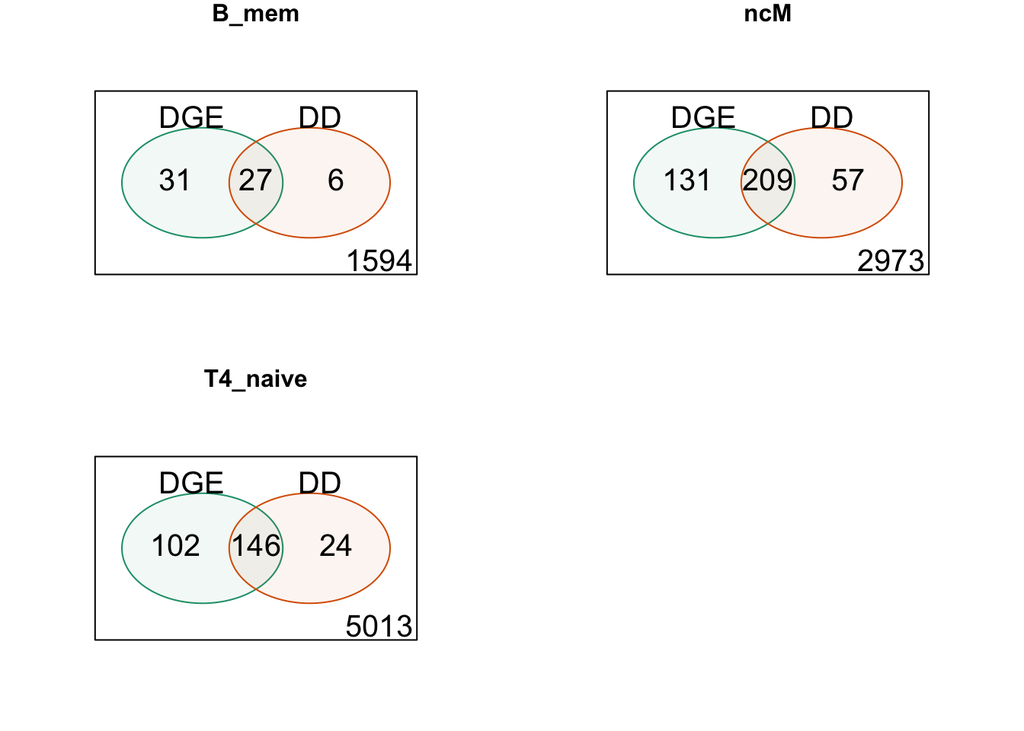

```r
par(mfrow=c(2,2))
for (j in seq_along(DD_res)) {
    pval_df <- data.frame(DGE = DGE_res[[j]]$PValue,
                          DD = DD_res[[j]]$PValue)
    rownames(pval_df) <- rownames(DGE_res[[j]])
    pad <- pval_df
    pad$DGE <- p.adjust(pad$DGE, method = "BH")
    pad$DD <- p.adjust(pad$DD, method = "BH")
    cobradata <- COBRAData(pval = pval_df, padj=pad)
    cobraperf <- calculate_performance(cobradata, splv = "none",maxsplit = 4)
    cobraplot <- prepare_data_for_plot(cobraperf, colorscheme = "Dark2", facetted = TRUE)
    plot_overlap(cobraplot, main=names(DD_res)[j])
}
```

# 14 Violin plots

Creating violin plots displaying genes that are DE, DD, or both, like we also did for the Covid case study. These figures are not included in the manuscript.

## 14.1 Bmem

```r
set.seed(77777)
figures_Bmem <- scatter_violin_paper(scatterplot = plotList[[1]],
                                     scatterplotData = plotDataList[[1]],
                                     violinplots_DD = DD_violins_Bmem,
                                     violinplots_DE = DGE_violins_Bmem,
                                     genes = targets,
                                     legend_position = c(0.9,0.35),
                                     nudge_x = c(-1,-1,1.5),
                                     nudge_y = c(1,1,-1))

png("./figures/violins_Bmem.png",
            width     = 12,
            height    = 8,
            res = 600,
            units = "in")

((figures_Bmem$topleft | figures_Bmem$topright) +
        plot_layout(guides = "keep")) /
    ((figures_Bmem$bottomleft | figures_Bmem$bottomright ) +
         plot_layout(guides = "collect"))
dev.off()
```

[output not shown]

## 14.2 ncM

```r
targets <- c("ENSG00000138496", "ENSG00000041357","ENSG00000104408")

DD_violins_ncM <- violin_DD(pb = pb_bin_list$ncM,
                            genes = targets)
DGE_violins_ncM <- violin_DGE(pb = pb_list$ncM,
                              genes = targets)
```

```r
set.seed(4634)
figures_ncM <- scatter_violin_paper(scatterplot = plotList[[2]],
                                    scatterplotData = plotDataList[[2]],
                                    violinplots_DD = DD_violins_ncM,
                                    violinplots_DE = DGE_violins_ncM,
                                    genes = targets,
                                    legend_position = c(0.9,0.35),
                                    nudge_x = c(-1,0,-0.5),
                                    nudge_y = c(1,-1.5,3))

png("./figures/violins_ncM.png",
            width     = 12,
            height    = 8,
            res = 600,
            units = "in")

((figures_ncM$topleft | figures_ncM$topright) +
        plot_layout(guides = "keep")) /
    ((figures_ncM$bottomleft | figures_ncM$bottomright ) +
         plot_layout(guides = "collect"))
dev.off()
```

## 14.3 T4naive

```r
targets <- c("ENSG00000082146", "ENSG00000101608","ENSG00000135486") # "ENSG00000127184"

DD_violins_T4naive <- violin_DD(pb = pb_bin_list$T4_naive,
                                genes = targets)
DGE_violins_T4naive <- violin_DGE(pb = pb_list$T4_naive,
                                  genes = targets)
```

```r
set.seed(6853)
figures_T4naive <- scatter_violin_paper(scatterplot = plotList[[3]],
                                    scatterplotData = plotDataList[[3]],
                                    violinplots_DD = DD_violins_T4naive,
                                    violinplots_DE = DGE_violins_T4naive,
                                    genes = targets,
                                    legend_position = c(0.9,0.35),
                                    nudge_x = c(0,0,2),
                                    nudge_y = c(1,-3,1))

png("./figures/violins_T4naive.png",
            width     = 12,
            height    = 8,
            res = 600,
            units = "in")

((figures_T4naive$topleft | figures_T4naive$topright) +
        plot_layout(guides = "keep")) /
    ((figures_T4naive$bottomleft | figures_T4naive$bottomright ) +
         plot_layout(guides = "collect"))
dev.off()
```

# 15 Get percentage 0-1-2-2+ for single-cell level dat

Here we obtain the fraction of counts that are zeros, ones, twos and values higher than two in the single-cell level data. This information is used in the discussion section of our manuscript.

```r
# B_mem
a_entries <- nrow(sce_list$B_mem)*ncol(sce_list$B_mem)
a_0 <- sum(assay(sce_list$B_mem) == 0)
a_1 <- sum(assay(sce_list$B_mem) == 1)
a_2 <- sum(assay(sce_list$B_mem) == 2)
a_r <- sum(assay(sce_list$B_mem) > 2)

# T4_naive
b_entries <- nrow(sce_list$T4_naive)*ncol(sce_list$T4_naive)
b_0 <- sum(assay(sce_list$T4_naive) == 0)
b_1 <- sum(assay(sce_list$T4_naive) == 1)
b_2 <- sum(assay(sce_list$T4_naive) == 2)
b_r <- sum(assay(sce_list$T4_naive) > 2)

# ncM
c_entries <- nrow(sce_list$ncM)*ncol(sce_list$ncM)
c_0 <- sum(assay(sce_list$ncM) == 0)
c_1 <- sum(assay(sce_list$ncM) == 1)
c_2 <- sum(assay(sce_list$ncM) == 2)
c_r <- sum(assay(sce_list$ncM) > 2)
```

```r
(a_0+b_0+c_0)/(a_entries+b_entries+c_entries)*100 # %0
```

```
## [1] 88.27565
```

```r
(a_1+b_1+c_1)/(a_entries+b_entries+c_entries)*100 # %1
```

```
## [1] 7.663693
```

```r
(a_2+b_2+c_2)/(a_entries+b_entries+c_entries)*100 # %2
```

```
## [1] 1.418609
```

```r
(a_r+b_r+c_r)/(a_entries+b_entries+c_entries)*100 # %2+
```

```
## [1] 2.64205
```